# INF2190_Final_Methods_Code

Karrie Chou

2022-11-26

# Loading and cleaning data

Data has been cleaned according to the process described in Michael Franke’s Introduction to Data Analysis, Appendix D.1. However, the clean data available in the package does not include two variables that we want to incorporate into our model: age and education.

## Coding categorical variables as numeric ones

To make analysis easier, binary variables of interest should be coded as numeric instead of categorical variables.

```r
mc_data_cleaned <- mc_data_cleaned %>%
  mutate(education_num = ifelse(education == "high school / college", 0, 1),
         handedness_num = ifelse(handedness == "left" | handedness == "Left", 0, 1),
         gender_num = ifelse(gender == "male", 0, 1))
```

## Summary statistics tables

Table 1: Summary statistics of handedness, education, and gender in the sample. For handedness_num, 0 refers to left-handed participants and 1 refers to right-handed participants. For education, 0 refers to participants whose highest completed level of education is high school or a college degree and 1 refers to participants whose highest completed level of education is a university degree. For gender, 0 refers to participants who identify as male and 1 refers to participants who identify as female.

[output not shown]

# Correlation tables and matrix

There are two models we can construct: one with the dependent variable being RT and another with the dependent variable being total_time_spent. First, we pull all of the characteristics we were interested in analyzing and compare their individual correlations with RT and total_time_spent. The independent variables of interest are: handedness, gender, age, and education.

Table 2: Correlations of each independent variable with RT.

| RT_handedness_cor | RT_gender_cor | RT_age_cor | RT_education_cor |
| --- | --- | --- | --- |
| 0.0116265 | 0.0380846 | 0.1632338 | -0.0840391 |

Table 3: Correlations of each independent variable with total_time_spent.

| time_handedness_cor | time_gender_cor | time_age_cor | time_education_cor |
| --- | --- | --- | --- |
| 0.0345605 | -0.1121461 | 0.0108126 | -0.0113043 |

Figure 1: Correlation matrix for each independent variable.

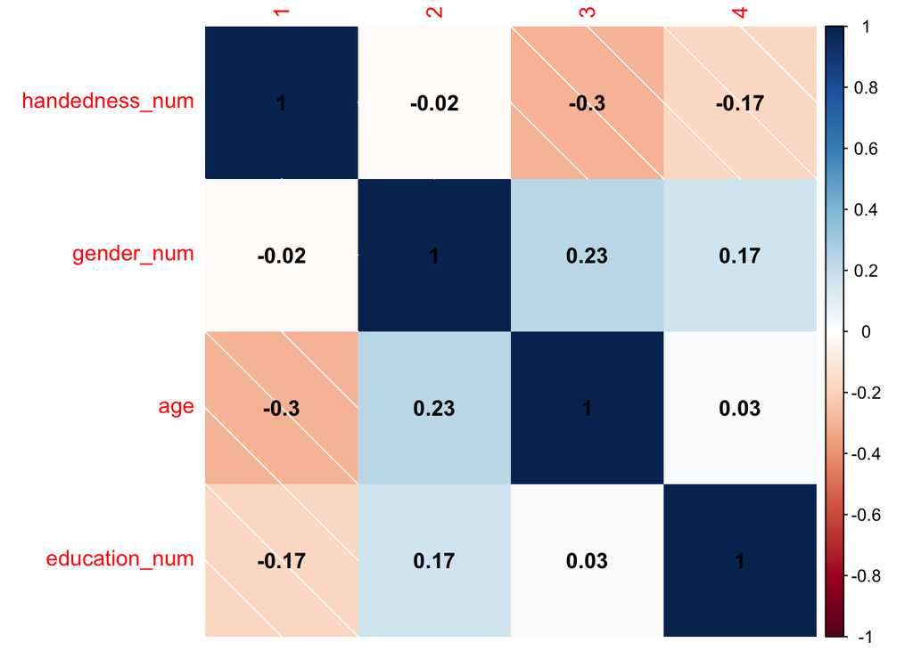

# Hypothesis testing

## Model 1: RT on demographic characteristics

We can construct a *multiple linear regression* of RT on each independent variable. To assess the significance of each independent variable, we assume $\alpha$ = 0.05.

```r
RT_lm_model <- lm(RT ~ handedness_num + gender_num + age + education_num,
                    data = mc_data_cleaned)
kable(summary(RT_lm_model)$coef)
```

|  | Estimate | Std. Error | t value | Pr(>\|t\|) |
| --- | --- | --- | --- | --- |
| (Intercept) | 314.1873739 | 18.0955822 | 17.3626563 | 0.0000000 |
| handedness_num | 31.0261037 | 13.3171146 | 2.3297918 | 0.0199033 |
| gender_num | 0.3952652 | 5.3387823 | 0.0740366 | 0.9409877 |
| age | 2.4881030 | 0.3151183 | 7.8957754 | 0.0000000 |
| education_num | -18.1250757 | 5.3575292 | -3.3831035 | 0.0007287 |

Handedness, age, and education all have a statistically significant relationship with reaction time.

## Model 2: total_time_spent on demographic characteristics

We can construct a *multiple linear regression* of total_time_spent on each independent variable. To assess the significance of each independent variable, we assume $\alpha$ = 0.05.

```r
time_lm_model <- lm(total_time_spent ~ handedness_num + gender_num + age + education_num,
                    data = mc_data_cleaned)
kable(summary(time_lm_model)$coef)
```

|  | Estimate | Std. Error | t value | Pr(>\|t\|) |
| --- | --- | --- | --- | --- |
| (Intercept) | 5.0846133 | 0.4583397 | 11.093548 | 0.0000000 |
| handedness_num | 0.8557832 | 0.3373068 | 2.537107 | 0.0112429 |
| gender_num | -0.9191645 | 0.1352250 | -6.797295 | 0.0000000 |
| age | 0.0199508 | 0.0079816 | 2.499613 | 0.0125021 |
| education_num | 0.1753357 | 0.1356999 | 1.292084 | 0.1964578 |

Handedness, gender, and age all have a statistically significant relationship with total time spent on all 3 reaction time tasks in the study.

# Plots

See JP’s code.

# NB classification exercise

## RT classification algorithm

Amano et al. (2006) conducted a study where eight participants were asked to watch a series of dots move on a screen and raise their finger when they first detected any motion. The study found that the participants react to a slight motion approximately 300 ms after it takes place, and that “the neural activites related to finger movement” were offset by approximately 130-200 ms. Using this finding as a benchmark, we will set 500 ms as the threshold for an ideal reaction time in any given task. For the classification algorithm, we need to create a categorical dummy variable which sorts each data point into a “good” reaction time and a “not good” reaction time. This will be captured in a variable named *good_reaction*.

### Setting up the training and test data:

```r
IV_w_RT_data <- cbind(IV_data, mc_data_cleaned$RT)
colnames(IV_w_RT_data) <- c("handedness_num", "gender_num", "age", "education_num", "RT")
IV_w_RT_data <- as.data.frame(IV_w_RT_data) %>%
  drop_na()
IV_w_RT_data <- IV_w_RT_data %>%
  mutate(good_reaction = ifelse(IV_w_RT_data$RT < 500, "Good", "Not good")) %>%
  select(handedness_num, gender_num, age, education_num, good_reaction)

set.seed(6)
training_samples_RT <- IV_w_RT_data$good_reaction %>%
  createDataPartition(p = 0.8, list = FALSE)
training_data_RT <- IV_w_RT_data[training_samples_RT, ]
test_data_RT <- IV_w_RT_data[-training_samples_RT, ]
```

### Creating the classification model, fitting it to training data, and letting it predict values for test data:

```r
RT_NB_classification_model <- train(good_reaction ~ .,
                                    data = training_data_RT,
                                    method = "nb",
                                    trControl = trainControl("cv", number = 10))
#print(RT_NB_classification_model)
RT_NB_classification_predict <- RT_NB_classification_model %>%
  predict(test_data_RT)
```

### Model accuracy:

```r
mean(RT_NB_classification_predict == test_data_RT$good_reaction)
```

```
## [1] 0.8065217
```

```r
kable(confusionMatrix(RT_NB_classification_predict, as.factor(test_data_RT$good_reaction))$table)
```

|  | Good | Not good |
| --- | --- | --- |
| Good | 371 | 89 |
| Not good | 0 | 0 |